# DATA_605_Final_Project

Md Jalal Uddin

December 18, 2016

```r
#Create function to download a package
#Sources:http://stackoverflow.com/questions/9341635/check-for-installed-packages-before-running-install-packages

packages <- function(x){
  x <- as.character(match.call()[[2]])
  if (!require(x,character.only=TRUE)){
    install.packages(pkgs=x,repos="http://cran.r-project.org")
    require(x,character.only=TRUE)
  }
}

#install required packages by using the created function.

#packages("cowplot")
#packages("caret")
#packages("Rmisc")
#packages("FactoMineR")
#packages("factoextra")
```

```r
library("stringr")
library("RCurl")
library("knitr")
library("rmongodb")
library("jsonlite")
library("dplyr")
library("sqldf")
library("tidyr")
```

```r
library("ggplot2")
library("rjson")
library("mongolite")
library("RMongo")
library("RMySQL")
library("DBI")
library("knitr")
library("RCurl")
library("ggplot2")
library("e1071")
library("dplyr")
library("scales")
library("cowplot")
library("MASS")
library("corrplot")
library("caret")
library("Rmisc")
library("FactoMineR")
library("factoextra")
```

```r
#Load the train data
Train_Data2 <- read.csv('C:/Users/sql_ent_svc/Desktop/DATA_605_Final_Project/train.CSV')

head (Train_Data2)
```

```
##   Id MSSubClass MSZoning LotFrontage LotArea Street Alley LotShape
## 1  1         60       RL          65    8450   Pave  <NA>      Reg
## 2  2         20       RL          80    9600   Pave  <NA>      Reg
## 3  3         60       RL          68   11250   Pave  <NA>      IR1
## 4  4         70       RL          60    9550   Pave  <NA>      IR1
## 5  5         60       RL          84   14260   Pave  <NA>      IR1
## 6  6         50       RL          85   14115   Pave  <NA>      IR1
##   LandContour Utilities LotConfig LandSlope Neighborhood Condition1
## 1         Lvl    AllPub    Inside       Gtl      CollgCr       Norm
## 2         Lvl    AllPub       FR2       Gtl      Veenker      Feedr
## 3         Lvl    AllPub    Inside       Gtl      CollgCr       Norm
## 4         Lvl    AllPub    Corner       Gtl      Crawfor       Norm
## 5         Lvl    AllPub       FR2       Gtl      NoRidge       Norm
## 6         Lvl    AllPub    Inside       Gtl      Mitchel       Norm
##   Condition2 BldgType HouseStyle OverallQual OverallCond YearBuilt
```

[output cut: 76 more lines]

```r
str(Train_Data2) #checking the characteristic of the variable
```

```
## 'data.frame':    1460 obs. of  81 variables:
##  $ Id           : int  1 2 3 4 5 6 7 8 9 10 ...
##  $ MSSubClass   : int  60 20 60 70 60 50 20 60 50 190 ...
##  $ MSZoning     : Factor w/ 5 levels "C (all)","FV",..: 4 4 4 4 4 4 4 4 5 4 ...
##  $ LotFrontage  : int  65 80 68 60 84 85 75 NA 51 50 ...
##  $ LotArea      : int  8450 9600 11250 9550 14260 14115 10084 10382 6120 7420 ...
##  $ Street       : Factor w/ 2 levels "Grvl","Pave": 2 2 2 2 2 2 2 2 2 2 ...
##  $ Alley        : Factor w/ 2 levels "Grvl","Pave": NA NA NA NA NA NA NA NA NA NA ...
##  $ LotShape     : Factor w/ 4 levels "IR1","IR2","IR3",..: 4 4 1 1 1 1 4 1 4 4 ...
##  $ LandContour  : Factor w/ 4 levels "Bnk","HLS","Low",..: 4 4 4 4 4 4 4 4 4 4 ...
##  $ Utilities    : Factor w/ 2 levels "AllPub","NoSeWa": 1 1 1 1 1 1 1 1 1 1 ...
##  $ LotConfig    : Factor w/ 5 levels "Corner","CulDSac",..: 5 3 5 1 3 5 5 1 5 1 ...
##  $ LandSlope    : Factor w/ 3 levels "Gtl","Mod","Sev": 1 1 1 1 1 1 1 1 1 1 ...
##  $ Neighborhood : Factor w/ 25 levels "Blmngtn","Blueste",..: 6 25 6 7 14 12 21 17 18 4 ...
##  $ Condition1   : Factor w/ 9 levels "Artery","Feedr",..: 3 2 3 3 3 3 3 5 1 1 ...
```

[output cut: 67 more lines]

```r
skewness(Train_Data2$SalePrice) #Checking skewness of the SalePrice variable
```

```
## [1] 1.879009
```

```r
skewness(Train_Data2$GrLivArea)#Checking skewness of the GrLivArea variable
```

```
## [1] 1.363754
```

```r
skewness(Train_Data2$GarageArea)#Checking skewness of the GarageArea variable
```

```
## [1] 0.1796113
```

From the above result I can see the variable SalePrice and GrLiveArea both are skewed to the right. So I will pick SalePrice variable as my Y variable and GrLiveArea variable as my X variable.

Probability: Calculate as a minimum the below probabilities a through c. Assume the small letter “x” is estimated as the 3d quartile of the X variable, and the small letter “y” is estimated as the 2d quartile of the Y variable. Interpret the meaning of all probabilities. In addition, make a table of counts as shown below.

```r
# GrLivArea
(xQ3 <- quantile(Train_Data2$GrLivArea, 0.75))
```

```
##     75%
## 1776.75
```

```r
# SalePrice
(yQ2 <- quantile(Train_Data2$SalePrice, 0.5))
```

```
##    50%
## 163000
```

(a)P(X>x | Y>y)

```r
numerator <- filter(Train_Data2, SalePrice > yQ2 & GrLivArea > xQ3) %>% tally()/nrow(Train_Data2)

denominator <- filter(Train_Data2, SalePrice > yQ2) %>% tally()/nrow(Train_Data2)

(a <- numerator/denominator)
```

```
##           n
## 1 0.4326923
```

(b)P(X>x, Y>y)

```r
b1 <- filter(Train_Data2, GrLivArea > xQ3) %>% tally()/nrow(Train_Data2)
b1
```

```
##      n
## 1 0.25
```

```r
b2 <- filter(Train_Data2, SalePrice > yQ2) %>% tally()/nrow(Train_Data2)

(b <- b1*b2)
```

```
##           n
## 1 0.1246575
```

```r
numerator1 <- filter(Train_Data2, SalePrice > yQ2 & GrLivArea < xQ3) %>% tally()/nrow(Train_Data2)

denominator1 <- filter(Train_Data2, SalePrice > yQ2) %>% tally()/nrow(Train_Data2)

(c <- numerator1/denominator1)
```

```
##           n
## 1 0.5673077
```

From the above calculation, we get the following result.

x/y <=2d quartile >2d quartile Total <=3d quartile 682 413 1095 >3d quartile 50 315 365 Total 732 728 1460

Proving Independency: The value of P(A/B) is equivalent to P(X>x/Y>y), which was shown above to be 0.4327. And P(A) X P(B)= P(X>x) X P(Y>y)= (365/1460)X(728/1460)= .1247 Hence P(A/B) not equal to P(X>x) X P(Y>y). So, the variable A and B are not independent.

Calculating a Chi square test

```r
# matrix values are from the table above
mat <- matrix(c( 682,  413,  50, 315), 2, 2, byrow=T)

chisq.test(mat, correct=TRUE)
```

```
##
##  Pearson's Chi-squared test with Yates' continuity correction
##
## data:  mat
## X-squared = 256.53, df = 1, p-value < 2.2e-16
```

The Chi-squared test indicates dependence between X and Y (GrLivArea and SalePrice).As the p-value is significantly less than the .05 (significance level), we reject the null hypothesis that the X is independent of Y.

Descriptive and Inferential Statistics: Provide univariate descriptive statistics and appropriate plots for the training data set. Provide a scatterplot of X and Y. Provide a 95% CI for the difference in the mean of the variables. Derive a correlation matrix for two of the quantitative variables you selected. Test the hypothesis that the correlation between these variables is 0 and provide a 99% confidence interval. Discuss the meaning of your analysis.

```r
# descriptive statistics on the numerical variables in the training dataset.

head(summary (Train_Data2))
```

```
##        Id           MSSubClass       MSZoning     LotFrontage
##  Min.   :   1.0   Min.   : 20.0   C (all):  10   Min.   : 21.00
##  1st Qu.: 365.8   1st Qu.: 20.0   FV     :  65   1st Qu.: 59.00
##  Median : 730.5   Median : 50.0   RH     :  16   Median : 69.00
##  Mean   : 730.5   Mean   : 56.9   RL     :1151   Mean   : 70.05
##  3rd Qu.:1095.2   3rd Qu.: 70.0   RM     : 218   3rd Qu.: 80.00
##  Max.   :1460.0   Max.   :190.0                  Max.   :313.00
##     LotArea        Street      Alley      LotShape  LandContour
##  Min.   :  1300   Grvl:   6   Grvl:  50   IR1:484   Bnk:  63
##  1st Qu.:  7554   Pave:1454   Pave:  41   IR2: 41   HLS:  50
##  Median :  9478               NA's:1369   IR3: 10   Low:  36
##  Mean   : 10517                           Reg:925   Lvl:1311
##  3rd Qu.: 11602
##  Max.   :215245
##   Utilities      LotConfig    LandSlope   Neighborhood   Condition1
##  AllPub:1459   Corner : 263   Gtl:1382   NAmes  :225   Norm   :1260
##  NoSeWa:   1   CulDSac:  94   Mod:  65   CollgCr:150   Feedr  :  81
##                FR2    :  47   Sev:  13   OldTown:113   Artery :  48
##                FR3    :   4              Edwards:100   RRAn   :  26
##                Inside :1052              Somerst: 86   PosN   :  19
##                                          Gilbert: 79   RRAe   :  11
##    Condition2     BldgType      HouseStyle   OverallQual
##  Norm   :1445   1Fam  :1220   1Story :726   Min.   : 1.000
##  Feedr  :   6   2fmCon:  31   2Story :445   1st Qu.: 5.000
##  Artery :   2   Duplex:  52   1.5Fin :154   Median : 6.000
##  PosN   :   2   Twnhs :  43   SLvl   : 65   Mean   : 6.099
##  RRNn   :   2   TwnhsE: 114   SFoyer : 37   3rd Qu.: 7.000
##  PosA   :   1                 1.5Unf : 14   Max.   :10.000
##   OverallCond      YearBuilt     YearRemodAdd    RoofStyle
##  Min.   :1.000   Min.   :1872   Min.   :1950   Flat   :  13
##  1st Qu.:5.000   1st Qu.:1954   1st Qu.:1967   Gable  :1141
##  Median :5.000   Median :1973   Median :1994   Gambrel:  11
##  Mean   :5.575   Mean   :1971   Mean   :1985   Hip    : 286
##  3rd Qu.:6.000   3rd Qu.:2000   3rd Qu.:2004   Mansard:   7
##  Max.   :9.000   Max.   :2010   Max.   :2010   Shed   :   2
##     RoofMatl     Exterior1st   Exterior2nd    MasVnrType    MasVnrArea
##  CompShg:1434   VinylSd:515   VinylSd:504   BrkCmn : 15   Min.   :   0.0
##  Tar&Grv:  11   HdBoard:222   MetalSd:214   BrkFace:445   1st Qu.:   0.0
##  WdShngl:   6   MetalSd:220   HdBoard:207   None   :864   Median :   0.0
##  WdShake:   5   Wd Sdng:206   Wd Sdng:197   Stone  :128   Mean   : 103.7
```

[output cut: 71 more lines]

```
##  Max.   :508.00   Max.   :480.00   Max.   :738.000
##    Fence      MiscFeature    MiscVal             MoSold
##  GdPrv:  59   Gar2:   2   Min.   :    0.00   Min.   : 1.000
##  GdWo :  54   Othr:   2   1st Qu.:    0.00   1st Qu.: 5.000
##  MnPrv: 157   Shed:  49   Median :    0.00   Median : 6.000
##  MnWw :  11   TenC:   1   Mean   :   43.49   Mean   : 6.322
##  NA's :1179   NA's:1406   3rd Qu.:    0.00   3rd Qu.: 8.000
##                           Max.   :15500.00   Max.   :12.000
##      YrSold        SaleType    SaleCondition    SalePrice
##  Min.   :2006   WD     :1267   Abnorml: 101   Min.   : 34900
##  1st Qu.:2007   New    : 122   AdjLand:   4   1st Qu.:129975
##  Median :2008   COD    :  43   Alloca :  12   Median :163000
##  Mean   :2008   ConLD  :   9   Family :  20   Mean   :180921
##  3rd Qu.:2009   ConLI  :   5   Normal :1198   3rd Qu.:214000
##  Max.   :2010   ConLw  :   5   Partial: 125   Max.   :755000
```

```r
#Summary statistics of two variables X (GrLivArea) and Y (SalePrice) are given below:

summary (Train_Data2$GrLivArea)
```

```
##    Min. 1st Qu.  Median    Mean 3rd Qu.    Max.
##     334    1130    1464    1515    1777    5642
```

```r
summary (Train_Data2$SalePrice)
```

```
##    Min. 1st Qu.  Median    Mean 3rd Qu.    Max.
##   34900  130000  163000  180900  214000  755000
```

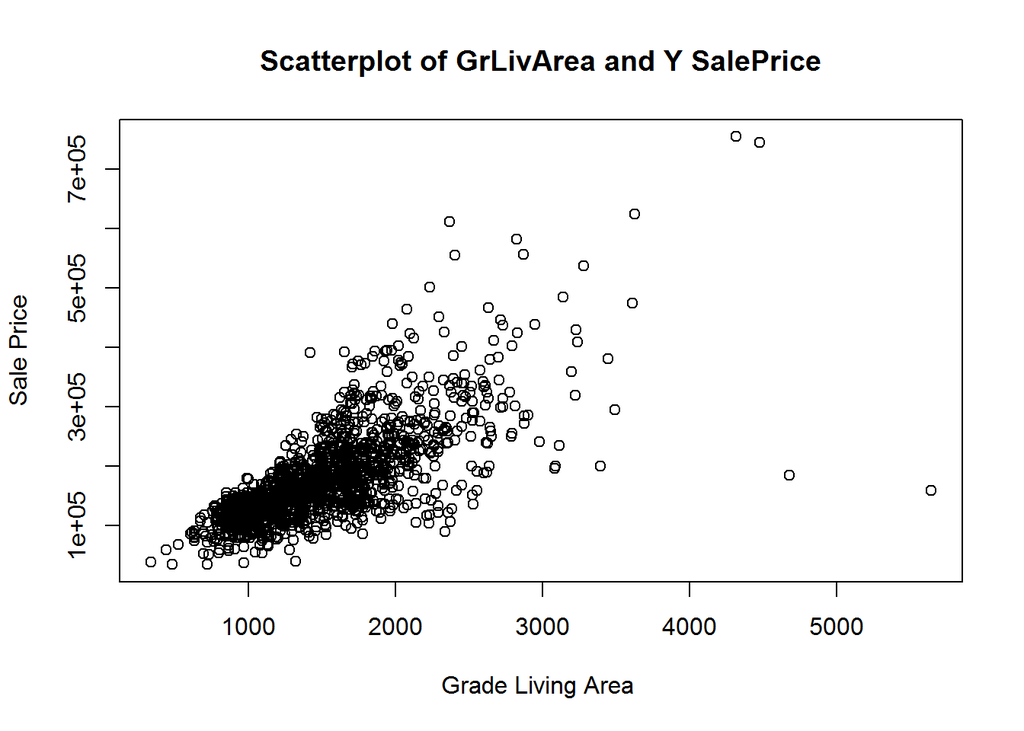

```r
# Simple Scatterplot of two variables X (GrLivArea) and Y (SalePrice)

plot(Train_Data2$GrLivArea, Train_Data2$SalePrice, main= "Scatterplot of GrLivArea and Y SalePrice",
    xlab="Grade Living Area ", ylab="Sale Price")
```

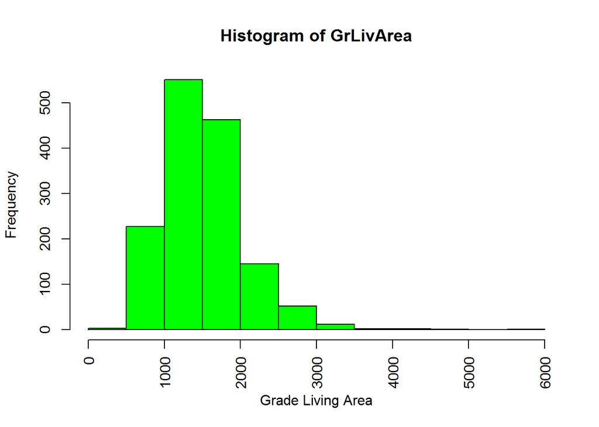

```r
hist(Train_Data2$GrLivArea, right = FALSE, main= "Histogram of GrLivArea",
    xlab ="Grade Living Area", col = "green", las=3, breaks=15)
```

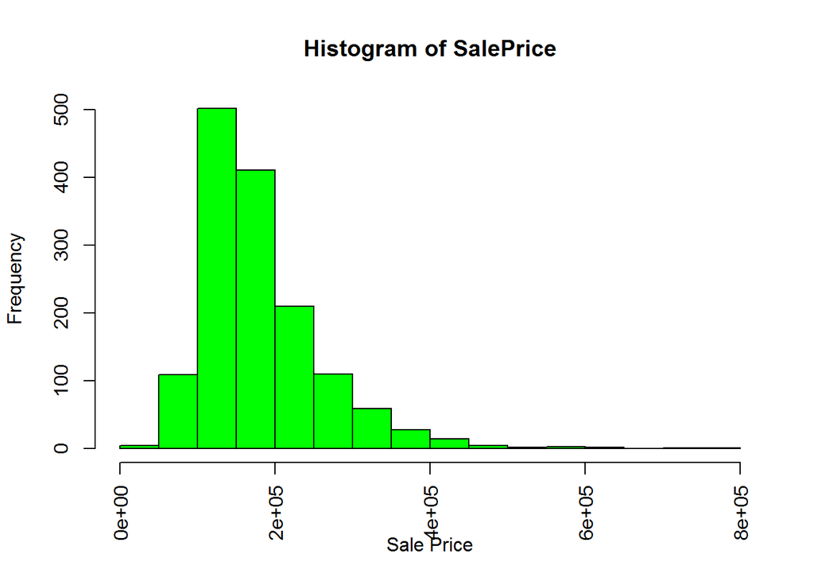

```r
hist(Train_Data2$SalePrice, right = FALSE, main= "Histogram of SalePrice",
    xlab ="Sale Price", col = "green", las=3.5, breaks=15)
```

Computing t.test between GrLivArea and SalePrice variable.

```r
t.test(Train_Data2$GrLivArea, Train_Data2$SalePrice)
```

```
##
##  Welch Two Sample t-test
##
## data:  Train_Data2$GrLivArea and Train_Data2$SalePrice
## t = -86.288, df = 1459.1, p-value < 2.2e-16
## alternative hypothesis: true difference in means is not equal to 0
## 95 percent confidence interval:
##  -183484.2 -175327.3
## sample estimates:
##  mean of x  mean of y
##   1515.464 180921.196
```

```r
library ("MASS")
#Correlation between GrLivArea and SalePrice

cor(Train_Data2$GrLivArea,Train_Data2$SalePrice)
```

```
## [1] 0.7086245
```

```r
#Sale price has strong positive correlation with grad Living area which mean if Grad Living area increase, Sale price also will increase.

#Correlation between other variables
names(Train_Data2)
```

```
##  [1] "Id"            "MSSubClass"    "MSZoning"      "LotFrontage"
##  [5] "LotArea"       "Street"        "Alley"         "LotShape"
##  [9] "LandContour"   "Utilities"     "LotConfig"     "LandSlope"
## [13] "Neighborhood"  "Condition1"    "Condition2"    "BldgType"
## [17] "HouseStyle"    "OverallQual"   "OverallCond"   "YearBuilt"
## [21] "YearRemodAdd"  "RoofStyle"     "RoofMatl"      "Exterior1st"
## [25] "Exterior2nd"   "MasVnrType"    "MasVnrArea"    "ExterQual"
## [29] "ExterCond"     "Foundation"    "BsmtQual"      "BsmtCond"
## [33] "BsmtExposure"  "BsmtFinType1"  "BsmtFinSF1"    "BsmtFinType2"
## [37] "BsmtFinSF2"    "BsmtUnfSF"     "TotalBsmtSF"   "Heating"
## [41] "HeatingQC"     "CentralAir"    "Electrical"    "X1stFlrSF"
## [45] "X2ndFlrSF"     "LowQualFinSF"  "GrLivArea"     "BsmtFullBath"
## [49] "BsmtHalfBath"  "FullBath"      "HalfBath"      "BedroomAbvGr"
## [53] "KitchenAbvGr"  "KitchenQual"   "TotRmsAbvGrd"  "Functional"
## [57] "Fireplaces"    "FireplaceQu"   "GarageType"    "GarageYrBlt"
## [61] "GarageFinish"  "GarageCars"    "GarageArea"    "GarageQual"
## [65] "GarageCond"    "PavedDrive"    "WoodDeckSF"    "OpenPorchSF"
## [69] "EnclosedPorch" "X3SsnPorch"    "ScreenPorch"   "PoolArea"
## [73] "PoolQC"        "Fence"         "MiscFeature"   "MiscVal"
## [77] "MoSold"        "YrSold"        "SaleType"      "SaleCondition"
## [81] "SalePrice"
```

```r
cor_data5 <- subset(Train_Data2, select=c("LotArea", "TotalBsmtSF","BsmtFinSF1", "GrLivArea","GarageArea", "PoolArea","SalePrice"))

names(cor_data5)
```

```
## [1] "LotArea"     "TotalBsmtSF" "BsmtFinSF1"  "GrLivArea"   "GarageArea"
## [6] "PoolArea"    "SalePrice"
```

```r
summary(cor_data5)
```

```
##     LotArea        TotalBsmtSF       BsmtFinSF1       GrLivArea
##  Min.   :  1300   Min.   :   0.0   Min.   :   0.0   Min.   : 334
##  1st Qu.:  7554   1st Qu.: 795.8   1st Qu.:   0.0   1st Qu.:1130
##  Median :  9478   Median : 991.5   Median : 383.5   Median :1464
##  Mean   : 10517   Mean   :1057.4   Mean   : 443.6   Mean   :1515
##  3rd Qu.: 11602   3rd Qu.:1298.2   3rd Qu.: 712.2   3rd Qu.:1777
##  Max.   :215245   Max.   :6110.0   Max.   :5644.0   Max.   :5642
##    GarageArea        PoolArea         SalePrice
##  Min.   :   0.0   Min.   :  0.000   Min.   : 34900
##  1st Qu.: 334.5   1st Qu.:  0.000   1st Qu.:129975
##  Median : 480.0   Median :  0.000   Median :163000
##  Mean   : 473.0   Mean   :  2.759   Mean   :180921
##  3rd Qu.: 576.0   3rd Qu.:  0.000   3rd Qu.:214000
##  Max.   :1418.0   Max.   :738.000   Max.   :755000
```

```r
(other <- cor(cor_data5))
```

```
##                LotArea TotalBsmtSF BsmtFinSF1 GrLivArea GarageArea
## LotArea     1.00000000   0.2608331  0.2141031 0.2631162 0.18040276
## TotalBsmtSF 0.26083313   1.0000000  0.5223961 0.4548682 0.48666546
## BsmtFinSF1  0.21410313   0.5223961  1.0000000 0.2081711 0.29697039
## GrLivArea   0.26311617   0.4548682  0.2081711 1.0000000 0.46899748
## GarageArea  0.18040276   0.4866655  0.2969704 0.4689975 1.00000000
## PoolArea    0.07767239   0.1260531  0.1404913 0.1702053 0.06104727
## SalePrice   0.26384335   0.6135806  0.3864198 0.7086245 0.62343144
##               PoolArea  SalePrice
## LotArea     0.07767239 0.26384335
## TotalBsmtSF 0.12605313 0.61358055
## BsmtFinSF1  0.14049129 0.38641981
## GrLivArea   0.17020534 0.70862448
## GarageArea  0.06104727 0.62343144
## PoolArea    1.00000000 0.09240355
## SalePrice   0.09240355 1.00000000
```

```r
str(Train_Data2)
```

```
## 'data.frame':    1460 obs. of  81 variables:
##  $ Id           : int  1 2 3 4 5 6 7 8 9 10 ...
##  $ MSSubClass   : int  60 20 60 70 60 50 20 60 50 190 ...
##  $ MSZoning     : Factor w/ 5 levels "C (all)","FV",..: 4 4 4 4 4 4 4 4 5 4 ...
##  $ LotFrontage  : int  65 80 68 60 84 85 75 NA 51 50 ...
##  $ LotArea      : int  8450 9600 11250 9550 14260 14115 10084 10382 6120 7420 ...
##  $ Street       : Factor w/ 2 levels "Grvl","Pave": 2 2 2 2 2 2 2 2 2 2 ...
##  $ Alley        : Factor w/ 2 levels "Grvl","Pave": NA NA NA NA NA NA NA NA NA NA ...
##  $ LotShape     : Factor w/ 4 levels "IR1","IR2","IR3",..: 4 4 1 1 1 1 4 1 4 4 ...
##  $ LandContour  : Factor w/ 4 levels "Bnk","HLS","Low",..: 4 4 4 4 4 4 4 4 4 4 ...
##  $ Utilities    : Factor w/ 2 levels "AllPub","NoSeWa": 1 1 1 1 1 1 1 1 1 1 ...
##  $ LotConfig    : Factor w/ 5 levels "Corner","CulDSac",..: 5 3 5 1 3 5 5 1 5 1 ...
##  $ LandSlope    : Factor w/ 3 levels "Gtl","Mod","Sev": 1 1 1 1 1 1 1 1 1 1 ...
##  $ Neighborhood : Factor w/ 25 levels "Blmngtn","Blueste",..: 6 25 6 7 14 12 21 17 18 4 ...
##  $ Condition1   : Factor w/ 9 levels "Artery","Feedr",..: 3 2 3 3 3 3 3 5 1 1 ...
```

[output cut: 67 more lines]

```r
#Similary, we can also forcast the variable relationship in regards with sale price by looking at the correlation coeficient.
```

Linear Algebra and Correlation: Invert your correlation matrix. (This is known as the precision matrix and contains variance inflation factors on the diagonal.) Multiply the correlation matrix by the precision matrix, and then multiply the precision matrix by the correlation matrix. Conduct principle components analysis (research this!)and interpret. Discuss.

```r
#Invert your correlation matrix. (This is known as the precision matrix and contains variance inflation factors on the diagonal.)

cor_data6 <- subset(Train_Data2, select=c("GrLivArea", "SalePrice")) #creating data to find correlation matrix and precision matrix.

(cor_matrix <- cor(cor_data6))
```

```
##           GrLivArea SalePrice
## GrLivArea 1.0000000 0.7086245
## SalePrice 0.7086245 1.0000000
```

```r
(Pre_matrix <- solve(cor_matrix)) #Precision matrix
```

```
##           GrLivArea SalePrice
## GrLivArea  2.008632 -1.423366
## SalePrice -1.423366  2.008632
```

```r
cor_matrix %*% Pre_matrix #Multiply correlation matrix by the precision matrix.
```

```
##           GrLivArea SalePrice
## GrLivArea         1         0
## SalePrice         0         1
```

```r
Pre_matrix %*% cor_matrix # Multiply precision matrix by correlation matrix
```

```
##           GrLivArea SalePrice
## GrLivArea         1         0
## SalePrice         0         1
```

```r
# After Both matrix operation it return the identity matrix.
```

Conducting principle components analysis,interpretition and Discussion.

```r
numeric_data2 <- Train_Data2[, which(sapply(Train_Data2, is.numeric))] #transforming data into numeric values

numeric_data2[is.na(numeric_data2[1:38])]<-0 #replacing NA values to zero.
head(numeric_data2)
```

```
##   Id MSSubClass LotFrontage LotArea OverallQual OverallCond YearBuilt
## 1  1         60          65    8450           7           5      2003
## 2  2         20          80    9600           6           8      1976
## 3  3         60          68   11250           7           5      2001
## 4  4         70          60    9550           7           5      1915
## 5  5         60          84   14260           8           5      2000
## 6  6         50          85   14115           5           5      1993
##   YearRemodAdd MasVnrArea BsmtFinSF1 BsmtFinSF2 BsmtUnfSF TotalBsmtSF
## 1         2003        196        706          0       150         856
## 2         1976          0        978          0       284        1262
## 3         2002        162        486          0       434         920
## 4         1970          0        216          0       540         756
## 5         2000        350        655          0       490        1145
## 6         1995          0        732          0        64         796
##   X1stFlrSF X2ndFlrSF LowQualFinSF GrLivArea BsmtFullBath BsmtHalfBath
```

[output cut: 27 more lines]

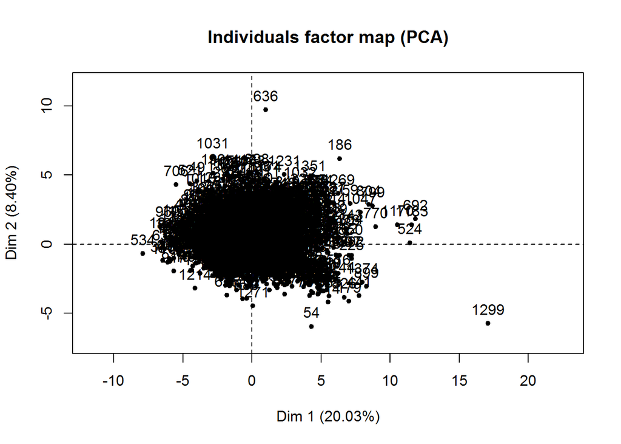

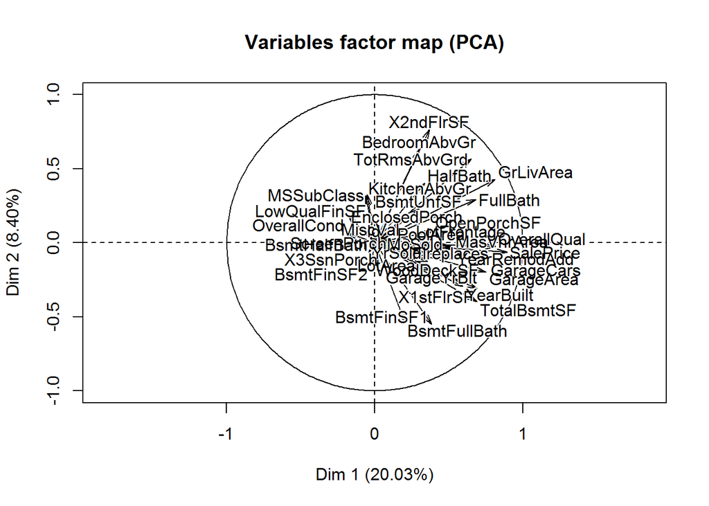

```r
numeric.pca = PCA(numeric_data2, scale.unit=TRUE, ncp=5, graph=T) #Finding Individual factor map and variables factor map.
```

```r
#numeric_data4 <- select(numeric_data1, MSSubClass,LotFrontage,LotArea, BsmtFinSF1,BsmtUnfSF, X1stFlrSF,GrLivArea, GarageArea, OpenPorchSF, PoolArea, SalePrice)

numeric_data5 <- subset(numeric_data2, select=c("MSSubClass","LotFrontage","LotArea", "BsmtFinSF1","BsmtUnfSF", "X1stFlrSF","GrLivArea", "GarageArea", "OpenPorchSF", "PoolArea", "SalePrice"))# Selecting the variable which are higher relationship among themselves.

head(numeric_data5)
```

```
##   MSSubClass LotFrontage LotArea BsmtFinSF1 BsmtUnfSF X1stFlrSF GrLivArea
## 1         60          65    8450        706       150       856      1710
## 2         20          80    9600        978       284      1262      1262
## 3         60          68   11250        486       434       920      1786
## 4         70          60    9550        216       540       961      1717
## 5         60          84   14260        655       490      1145      2198
## 6         50          85   14115        732        64       796      1362
##   GarageArea OpenPorchSF PoolArea SalePrice
## 1        548          61        0    208500
## 2        460           0        0    181500
## 3        608          42        0    223500
## 4        642          35        0    140000
## 5        836          84        0    250000
## 6        480          30        0    143000
```

```r
#Transforming the variable into numeric data.
numeric_data5 <- transform(numeric_data5,  MSSubClass = as.numeric( MSSubClass))
numeric_data5 <- transform(numeric_data5,  LotFrontage = as.numeric( LotFrontage))
numeric_data5 <- transform(numeric_data5,  LotArea = as.numeric( LotArea))
numeric_data5 <- transform(numeric_data5, BsmtFinSF1 = as.numeric(BsmtFinSF1))
numeric_data5 <- transform(numeric_data5,  BsmtUnfSF = as.numeric(BsmtUnfSF))
numeric_data5 <- transform(numeric_data5,  X1stFlrSF = as.numeric( X1stFlrSF))
numeric_data5 <- transform(numeric_data5,  GrLivArea = as.numeric( GrLivArea))
numeric_data5 <- transform(numeric_data5,  GarageArea = as.numeric( GarageArea))
numeric_data5 <- transform(numeric_data5, OpenPorchSF = as.numeric( OpenPorchSF))
numeric_data5 <- transform(numeric_data5,  PoolArea = as.numeric(  PoolArea))
numeric_data5 <- transform(numeric_data5, SalePrice = as.numeric( SalePrice))

str(numeric_data5) # for checking variable characteristic
```

```
## 'data.frame':    1460 obs. of  11 variables:
##  $ MSSubClass : num  60 20 60 70 60 50 20 60 50 190 ...
##  $ LotFrontage: num  65 80 68 60 84 85 75 0 51 50 ...
##  $ LotArea    : num  8450 9600 11250 9550 14260 ...
##  $ BsmtFinSF1 : num  706 978 486 216 655 ...
##  $ BsmtUnfSF  : num  150 284 434 540 490 64 317 216 952 140 ...
##  $ X1stFlrSF  : num  856 1262 920 961 1145 ...
##  $ GrLivArea  : num  1710 1262 1786 1717 2198 ...
##  $ GarageArea : num  548 460 608 642 836 480 636 484 468 205 ...
##  $ OpenPorchSF: num  61 0 42 35 84 30 57 204 0 4 ...
##  $ PoolArea   : num  0 0 0 0 0 0 0 0 0 0 ...
##  $ SalePrice  : num  208500 181500 223500 140000 250000 ...
```

```r
(my.cov <- cov(numeric_data5)) #finding covariance matrix
```

```
##                MSSubClass LotFrontage      LotArea   BsmtFinSF1
## MSSubClass     1789.33831   -315.2923    -59017.42    -1347.356
## LotFrontage    -315.29233   1201.6140     34854.98     1212.177
## LotArea      -59017.41863  34854.9839  99625649.65   974690.774
## BsmtFinSF1    -1347.35575   1212.1774    974690.77   208025.468
## BsmtUnfSF     -2630.96706   2463.4237    -11547.99   -99810.344
## X1stFlrSF     -4116.97464   3285.6194   1155562.98    78615.364
## GrLivArea      1663.84548   4013.7156   1380033.49    49892.500
## GarageArea     -892.39204   1493.1988    384987.19    28959.358
## OpenPorchSF     -17.09661    159.8630     56062.53     3377.322
## PoolArea         14.07665    158.9180     31148.21     2574.474
## SalePrice   -283233.73723 577266.4207 209211069.94 14001370.605
##                BsmtUnfSF    X1stFlrSF    GrLivArea    GarageArea
## MSSubClass    -2630.9671    -4116.975     1663.845     -892.3920
## LotFrontage    2463.4237     3285.619     4013.716     1493.1988
## LotArea      -11547.9915  1155562.980  1380033.489   384987.1947
## BsmtFinSF1   -99810.3438    78615.364    49892.500    28959.3582
## BsmtUnfSF    195246.4062    54318.724    55785.916    17317.2097
## X1stFlrSF     54318.7245   149450.079   114984.528    40482.5745
## GrLivArea     55785.9159   114984.528   276129.633    52691.9839
## GarageArea    17317.2097    40482.574    52691.984    45712.5102
## OpenPorchSF    3776.8076     5421.698    11497.158     3420.1296
## PoolArea       -622.9934     2042.853     3593.441      524.4023
## SalePrice   7528863.6602 18606627.852 29581866.743 10589102.5227
##               OpenPorchSF     PoolArea    SalePrice
## MSSubClass      -17.09661     14.07665    -283233.7
## LotFrontage     159.86302    158.91802     577266.4
## LotArea       56062.52757  31148.20938  209211069.9
## BsmtFinSF1     3377.32166   2574.47374   14001370.6
## BsmtUnfSF      3776.80757   -622.99340    7528863.7
## X1stFlrSF      5421.69763   2042.85305   18606627.9
## GrLivArea     11497.15764   3593.44086   29581866.7
## GarageArea     3420.12964    524.40234   10589102.5
## OpenPorchSF    4389.86120    161.74806    1662523.4
## PoolArea        161.74806   1614.21599     294932.3
## SalePrice   1662523.36063 294932.33924 6311111264.3
```

```r
(cor_mat1 <- cor(numeric_data5)) #finding correlation coefficient among themselves.
```

```
##               MSSubClass LotFrontage     LotArea  BsmtFinSF1   BsmtUnfSF
## MSSubClass   1.000000000 -0.21502289 -0.13978108 -0.06983575 -0.14075948
## LotFrontage -0.215022886  1.00000000  0.10073881  0.07667000  0.16082928
## LotArea     -0.139781082  0.10073881  1.00000000  0.21410313 -0.00261836
## BsmtFinSF1  -0.069835749  0.07667000  0.21410313  1.00000000 -0.49525147
## BsmtUnfSF   -0.140759481  0.16082928 -0.00261836 -0.49525147  1.00000000
## X1stFlrSF   -0.251758352  0.24518093  0.29947458  0.44586266  0.31798744
## GrLivArea    0.074853180  0.22034723  0.26311617  0.20817113  0.24025727
## GarageArea  -0.098671543  0.20147335  0.18040276  0.29697039  0.18330270
## OpenPorchSF -0.006100121  0.06960495  0.08477381  0.11176061  0.12900541
## PoolArea     0.008282708  0.11410636  0.07767239  0.14049129 -0.03509224
## SalePrice   -0.084284135  0.20962394  0.26384335  0.38641981  0.21447911
##              X1stFlrSF  GrLivArea  GarageArea  OpenPorchSF     PoolArea
## MSSubClass  -0.2517584 0.07485318 -0.09867154 -0.006100121  0.008282708
## LotFrontage  0.2451809 0.22034723  0.20147335  0.069604952  0.114106359
## LotArea      0.2994746 0.26311617  0.18040276  0.084773809  0.077672392
## BsmtFinSF1   0.4458627 0.20817113  0.29697039  0.111760613  0.140491286
## BsmtUnfSF    0.3179874 0.24025727  0.18330270  0.129005415 -0.035092241
## X1stFlrSF    1.0000000 0.56602397  0.48978165  0.211671225  0.131524976
## GrLivArea    0.5660240 1.00000000  0.46899748  0.330223962  0.170205336
## GarageArea   0.4897817 0.46899748  1.00000000  0.241434672  0.061047272
## OpenPorchSF  0.2116712 0.33022396  0.24143467  1.000000000  0.060762111
## PoolArea     0.1315250 0.17020534  0.06104727  0.060762111  1.000000000
## SalePrice    0.6058522 0.70862448  0.62343144  0.315856227  0.092403549
##               SalePrice
## MSSubClass  -0.08428414
## LotFrontage  0.20962394
## LotArea      0.26384335
## BsmtFinSF1   0.38641981
## BsmtUnfSF    0.21447911
## X1stFlrSF    0.60585218
## GrLivArea    0.70862448
## GarageArea   0.62343144
## OpenPorchSF  0.31585623
## PoolArea     0.09240355
## SalePrice    1.00000000
```

Finding correlation matrix graphical picture. From the graphical observation we can see variable GrLivArea has strong positive relation ship with SalePrice since the picture shows the intersection of both of the box is dark blue.

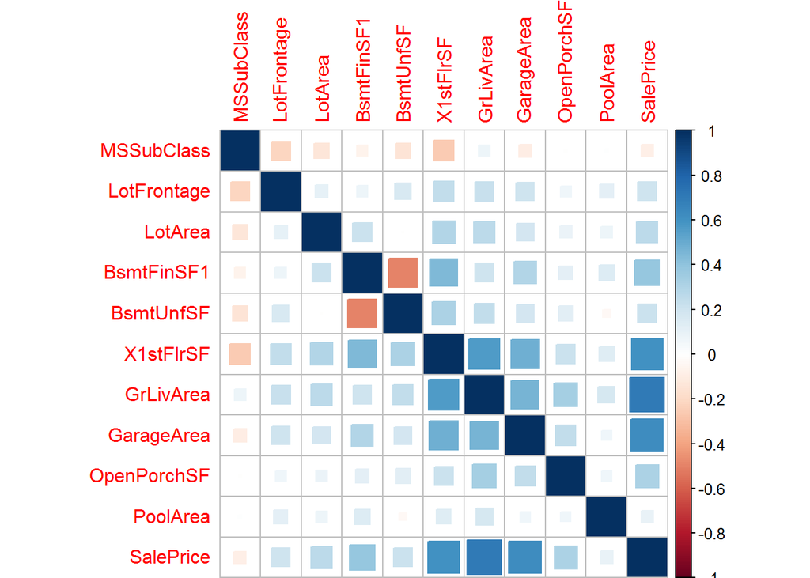

```r
corrplot(cor_mat1, method="square")
```

X1stFlrSF, GrLivArea, and GarageArea are the mostly highly correlated variables, with SalePrice being the highest at 0.70862448.

```r
library("MASS") #loading package
min(Train_Data2$GrLivArea)
```

```
## [1] 334
```

```r
(GrLivArea1 <- Train_Data2$GrLivArea + .00000001)
```

[output not shown]

[output cut: 98 more lines]

```r
#finding the exponential distribution

fit <- fitdistr(GrLivArea1, "exponential")

# find lambda

(lambda <- fit$estimate)
```

```
##        rate
## 0.000659864
```

```r
#Creating 1000 sample data
sample <- rexp(1000, lambda)
```

[figure not shown]

```r
hist(Train_Data2$GrLivArea, right = FALSE, main= "Histogram of stimulated GrLivArea",
    xlab ="Grade Living Area", col = "green", las=.1, breaks=20)
```

[figure not shown]

```r
hist(sample, right = FALSE, main= "Histogram of Observed GrLivArea",
    xlab ="Grade Living Area", col = "green", las=.1, breaks=20)
```

Using the exponential pdf, find the 5th and 95th percentiles using the cumulative distribution function (CDF).

Percentile is given by:

```r
# simulated
(cdf.p5 <- log(1 - .05)/-lambda)  #5th percentile stimulated GrLivArea
```

```
##     rate
## 77.73313
```

```r
(csf.p95 <- log(1 - .95)/-lambda)  # 95th percentile stimulated GrLivArea
```

```
##     rate
## 4539.924
```

```r
(obs.p5 <- quantile(Train_Data2$GrLivArea, 0.05)) # 5th percentile observed GrLivArea
```

```
##  5%
## 848
```

```r
(obs.p95 <- quantile(Train_Data2$GrLivArea, 0.95)) # 95th percentile observed GrLivArea
```

```
##    95%
## 2466.1
```

Calculated a 95% confidence interval from the empirical data, assuming normality.

```r
CI(Train_Data2$GrLivArea, 0.95)
```

```
##    upper     mean    lower
## 1542.440 1515.464 1488.487
```

With 95% confidence, the mean of GrLivArea is between 1488.487 and 1542.440. The exponential distribution would not be a good fit in this case. We see that the center of the exponential distribution is shifted left as compared the empirical data. Additionally we see more spread in the exponential distribution.

Modeling: Build some type of regression model and submit your model to the competition board. Provide your complete model summary and results with analysis. Report your Kaggle.com user name and score.

```r
#Transform the data into numeric value.
numeric_var1 <- Train_Data2[, which(sapply(Train_Data2, is.numeric))]

(rfFit <-(lm(SalePrice ~.,
              numeric_var1))) # fit the model of the Train_Data2.
```

```
##
## Call:
## lm(formula = SalePrice ~ ., data = numeric_var1)
##
## Coefficients:
##   (Intercept)             Id     MSSubClass    LotFrontage        LotArea
##    -3.351e+05     -1.205e+00     -2.001e+02     -1.160e+02      5.422e-01
##   OverallQual    OverallCond      YearBuilt   YearRemodAdd     MasVnrArea
##     1.866e+04      5.239e+03      3.164e+02      1.194e+02      3.141e+01
##    BsmtFinSF1     BsmtFinSF2      BsmtUnfSF    TotalBsmtSF      X1stFlrSF
##     1.736e+01      8.342e+00      5.005e+00             NA      4.597e+01
##     X2ndFlrSF   LowQualFinSF      GrLivArea   BsmtFullBath   BsmtHalfBath
##     4.663e+01      3.341e+01             NA      9.043e+03      2.465e+03
##      FullBath       HalfBath   BedroomAbvGr   KitchenAbvGr   TotRmsAbvGrd
##     5.433e+03     -1.098e+03     -1.022e+04     -2.202e+04      5.464e+03
##    Fireplaces    GarageYrBlt     GarageCars     GarageArea     WoodDeckSF
##     4.372e+03     -4.728e+01      1.685e+04      6.274e+00      2.144e+01
##   OpenPorchSF  EnclosedPorch     X3SsnPorch    ScreenPorch       PoolArea
##    -2.252e+00      7.295e+00      3.349e+01      5.805e+01     -6.052e+01
##       MiscVal         MoSold         YrSold
##    -3.761e+00     -2.217e+02     -2.474e+02
```

```r
# select variables with no NA values
step_data <- Train_Data2[, which(sapply(Train_Data2, function(x) sum(is.na(x))) == 0)]
# prepare stepwise model using all non-NA variables
stepback <- step(lm(SalePrice ~ ., step_data), direction = 'backward', trace = FALSE)
stepback
```

```
##
## Call:
## lm(formula = SalePrice ~ MSZoning + LotArea + Street + LandContour +
##     LotConfig + LandSlope + Neighborhood + Condition1 + Condition2 +
##     BldgType + HouseStyle + OverallQual + OverallCond + YearBuilt +
##     YearRemodAdd + RoofStyle + RoofMatl + ExterQual + Foundation +
##     BsmtFinSF1 + BsmtFinSF2 + BsmtUnfSF + X1stFlrSF + X2ndFlrSF +
##     FullBath + BedroomAbvGr + KitchenAbvGr + KitchenQual + TotRmsAbvGrd +
##     Functional + Fireplaces + GarageCars + GarageArea + WoodDeckSF +
##     ScreenPorch + PoolArea + MoSold + SaleType, data = step_data)
##
## Coefficients:
##         (Intercept)           MSZoningFV           MSZoningRH
##          -1.590e+06            3.081e+04            2.235e+04
##          MSZoningRL           MSZoningRM              LotArea
##           2.500e+04            2.399e+04            7.290e-01
##          StreetPave       LandContourHLS       LandContourLow
##           3.855e+04            1.455e+04           -4.130e+03
##      LandContourLvl     LotConfigCulDSac         LotConfigFR2
##           7.223e+03            7.028e+03           -5.531e+03
##        LotConfigFR3      LotConfigInside         LandSlopeMod
##          -1.330e+04           -1.009e+03            1.085e+04
##        LandSlopeSev  NeighborhoodBlueste   NeighborhoodBrDale
##          -3.134e+04            1.053e+03            7.068e+03
## NeighborhoodBrkSide  NeighborhoodClearCr  NeighborhoodCollgCr
##          -4.220e+02           -1.098e+04           -7.826e+03
## NeighborhoodCrawfor  NeighborhoodEdwards  NeighborhoodGilbert
##           8.985e+03           -1.417e+04           -1.344e+04
##  NeighborhoodIDOTRR  NeighborhoodMeadowV  NeighborhoodMitchel
##          -4.029e+03            3.845e+02           -1.931e+04
##   NeighborhoodNAmes  NeighborhoodNoRidge  NeighborhoodNPkVill
##          -1.268e+04            2.977e+04            4.911e+03
## NeighborhoodNridgHt   NeighborhoodNWAmes  NeighborhoodOldTown
##           2.459e+04           -2.299e+04           -1.200e+04
##  NeighborhoodSawyer  NeighborhoodSawyerW  NeighborhoodSomerst
##          -1.195e+04           -8.005e+03            1.200e+03
## NeighborhoodStoneBr    NeighborhoodSWISU   NeighborhoodTimber
##           3.612e+04           -5.338e+03           -6.451e+03
## NeighborhoodVeenker      Condition1Feedr       Condition1Norm
##           2.206e+03            3.626e+03            1.171e+04
```

[output cut: 39 more lines]

```
##          -2.836e+04           -2.611e+04            1.555e+03
##      FunctionalMaj2       FunctionalMin1       FunctionalMin2
##          -9.426e+02            1.685e+03            9.192e+03
##       FunctionalMod        FunctionalSev        FunctionalTyp
##          -4.378e+03           -7.531e+04            1.799e+04
##          Fireplaces           GarageCars           GarageArea
##           2.944e+03            3.978e+03            1.328e+01
##          WoodDeckSF          ScreenPorch             PoolArea
##           9.906e+00            3.173e+01            7.234e+01
##              MoSold          SaleTypeCon        SaleTypeConLD
##          -5.716e+02            4.523e+04            1.747e+04
##       SaleTypeConLI        SaleTypeConLw          SaleTypeCWD
##           1.142e+04            6.004e+03            2.210e+04
##         SaleTypeNew          SaleTypeOth           SaleTypeWD
##           2.361e+04            1.601e+04            5.139e+03
```

We have find the following model from the data above: Linear model of the data for Sale Price is: SalePrice ~ MSZoning + LotArea + Street + LandContour + LotConfig + LandSlope + Neighborhood + Condition1 + Condition2 + BldgType + HouseStyle + OverallQual + OverallCond + YearBuilt + YearRemodAdd + RoofStyle + RoofMatl + ExterQual + Foundation + BsmtFinSF1 + BsmtFinSF2 + BsmtUnfSF + X1stFlrSF + X2ndFlrSF + FullBath + BedroomAbvGr + KitchenAbvGr + KitchenQual + TotRmsAbvGrd + Functional + Fireplaces + GarageCars + GarageArea + WoodDeckSF + ScreenPorch + PoolArea + MoSold + SaleType